# Week_4_Project

### **Part 1 (15 Points)**

```python
plan_to_purchase_Actually_Placed_order = 400
Total_Planned_to_purcahse = 2000
join_Prob_plan_to_purchase_Actually_Placed_order = 400/2000
print('The joint probability of the people who planned to purchase and actually placed an order is %1.2f' %join_Prob_plan_to_purchase_Actually_Placed_order)
```

```
The joint probability of the people who planned to purchase and actually placed an order is 0.20
```

The joint probability of the people who planned to purchase and actually placed an order is **0.20**

```python
plan_to_purchase_Actually_Placed_order = 400
given_people_planned_to_purchase = 500
join_Prob_plan_to_purchase_Actually_Placed_order_Given_People_plantopurchase = 400/500
print('The joint probability of the people who planned to purchase and actually placed an order, given that people planned to purchase is %1.2f' %join_Prob_plan_to_purchase_Actually_Placed_order_Given_People_plantopurchase)
```

```
The joint probability of the people who planned to purchase and actually placed an order, given that people planned to purchase is 0.80
```

The joint probability of the people who planned to purchase and actually placed an order, given that people planned to purchase is **0.80**

Q2. An electrical manufacturing company conducts quality checks at specified periods on the products it manufactures. Historically, the failure rate for the manufactured item is 5%. Suppose a random sample of 10 manufactured items is selected. Answer the following questions. (4 points)

```python
import numpy as np
import scipy.stats as stats
import matplotlib.pyplot as plt
#This is a binomial problem. Each selection is independent of one another, and a manufactured item is either defective or it is not defective.

p = 0.05 # is the probability of being defective
n = 10 #is randomly selected
k=np.arange(0,11)
k
```

```
array([ 0,  1,  2,  3,  4,  5,  6,  7,  8,  9, 10])
```

```python
binomial = stats.binom.pmf(k,n,p)
binomial
```

```
array([5.98736939e-01, 3.15124705e-01, 7.46347985e-02, 1.04750594e-02,
       9.64808106e-04, 6.09352488e-05, 2.67259863e-06, 8.03789062e-08,
       1.58642578e-09, 1.85546875e-11, 9.76562500e-14])
```

1. Probability that none of the items are defective? (1 point)

```python
print('Probability that none of the items are defective is %1.4f' %binomial[0])
```

```
Probability that none of the items are defective is 0.5987
```

Probability that none of the items are defective is **0.5987**

1. Probability that exactly one of the items is defective? (1 point)

```python
print('Probability that exactly one of the items is defective is %1.4f' %binomial[1])
```

```
Probability that exactly one of the items is defective is 0.3151
```

Probability that exactly one of the items is defective is **0.3151**

1. Probability that two or fewer of the items are defective? (1 point)

```python
print('Probability that two or fewer of the items are defective is %1.4f' %(binomial[0]+binomial[1]+binomial[2]))
```

```
Probability that two or fewer of the items are defective is 0.9885
```

Probability that two or fewer of the items are defective is **0.9885**

1. Probability that three or more of the items are defective ? (1 point)

```python
print('Probability that three or more of the items are defective is %1.4f' %(binomial[3]+binomial[4]+binomial[5]+binomial[6]+binomial[7]))
```

```
Probability that three or more of the items are defective is 0.0115
```

Probability that three or more of the items are defective is **0.0115**

Q3. A car salesman sells on an average 3 cars per week. (3 points)

```python
#Assuming the car salesman's weekly sales follow a Poisson distribution (a common choice for modeling the number of events happening in a fixed interval of time)

from scipy.stats import poisson
```

1. Probability that in a given week he will sell some cars. (1 point)

```python
# "Some cars" means "1 or more cars". We can work this out by finding 1 minus the "zero car" probability

# Find zero car probability
pmf = poisson.pmf(0,3)
pmf
```

```
0.049787068367863944
```

```python
# Therefore the probability of selling 1 or more cars is given by:
probability_sells_some_cars = 1- pmf
print('Probability that in a given week he will sell some cars is  %1.4f' %probability_sells_some_cars)
```

```
Probability that in a given week he will sell some cars is  0.9502
```

Probability that in a given week he will sell some cars is **0.9502**

1. Probability that in a given week he will sell 2 or more but less than 5 cars. (1 point)

```python
# Calculate the probability of selling 2, 3, or 4 cars
probability_two = poisson.pmf(2,3)
probability_three = poisson.pmf(3,3)
probability_four = poisson.pmf(4,3)

# Calculate the probability of selling 2 or more but less than 5 cars
Total_probability_two_or_more_but_less_tha_5_cars = probability_two + probability_three + probability_four

print('Probability that in a given week he will sell 2 or more but less than 5 cars is  %1.4f' %Total_probability_two_or_more_but_less_tha_5_cars)
```

```
Probability that in a given week he will sell 2 or more but less than 5 cars is  0.6161
```

Probability that in a given week he will sell 2 or more but less than 5 cars is **0.6161**

1. Plot the poisson distribution function for cumulative probability of cars sold per-week vs number of cars sold per- week. (1 point)

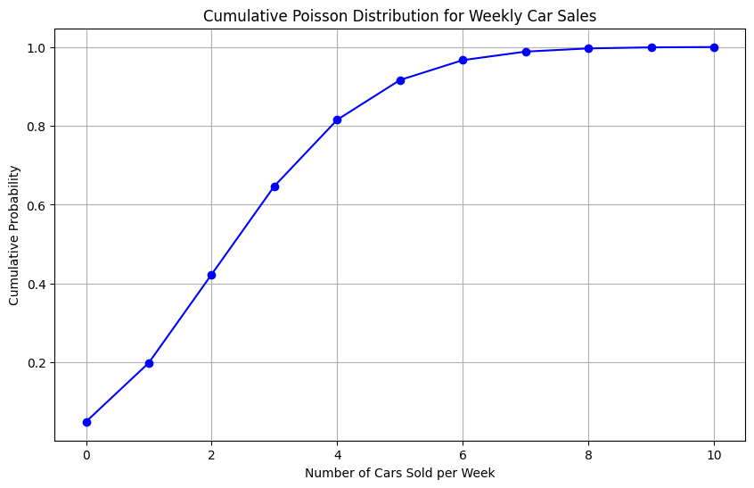

```python
import matplotlib.pyplot as plt

# Create an array of x values (number of cars sold per week)
X = [0, 1, 2, 3, 4, 5, 6 ,7, 8, 9, 10]
lmbda = 3

# Calculate the cumulative probabilities for each x value
poisson_pd = poisson.cdf(X, lmbda)

# Plot the probability distribution
plt.figure(figsize=(10, 6))
plt.plot(X, poisson_pd, marker='o', linestyle='-', color='b')
plt.title('Cumulative Poisson Distribution for Weekly Car Sales')
plt.xlabel('Number of Cars Sold per Week')
plt.ylabel('Cumulative Probability')
plt.grid(True)
plt.show()
```

Q4. Accuracy in understanding orders for a speech based bot at a restaurant is important for the Company X which has designed, marketed, and launched the product for a contactless delivery due to the COVID-19 pandemic. Recognition accuracy that measures the percentage of orders that are taken correctly is 86.8%. Suppose that you place an order with the bot and two friends of yours independently place orders with the same bot. Answer the following questions. (3 points)

```python
import numpy as np
import pandas as pd
import scipy.stats as stats
import matplotlib.pyplot as plt
from scipy.stats import binom
import matplotlib.pyplot as plt

p   =  0.868 # percentage of orders filled correctly at Wendy's was approximately 86.8%
n   =  3
k = np.arange(0,4)

binomial = stats.binom.pmf(k,n,p)
print(binomial)
```

```
[0.00229997 0.0453721  0.2983559  0.65397203]
```

1. What is the probability that all three orders will be recognised correctly?

```python
print('Probability that all three orders will be recognised correctly is %1.4f' %binomial[3])
```

```
Probability that all three orders will be recognised correctly is 0.6540
```

Probability that all three orders will be recognised correctly is **0.6540**

1. What is the probability that none of the three orders will be recognised correctly? (1 point)

```python
print('Probability that none of the three orders will be recognised correctly is %1.4f' %binomial[0])
```

```
Probability that none of the three orders will be recognised correctly is 0.0023
```

Probability that none of the three orders will be recognised correctly is **0.0023**

1. What is the probability that at least two of the three orders will be recognised correctly?(1 point)

```python
cumbinomial = stats.binom.cdf(k,n,p)
P = 1 - cumbinomial[1]
print('Probability that at least two of the three orders will be recognised correctly is %1.4f' % P)
```

```
Probability that at least two of the three orders will be recognised correctly is 0.9523
```

Probability that at least two of the three orders will be recognised correctly is **0.9523**

Q5. A group of 300 professionals sat for a competitive exam. The results show the information of marks obtained by them have a mean of 60 and a standard deviation of 12. The pattern of marks follows a normal distribution. Answer the following questions. (3 points)

```python
X = 300
µ = 60
sigma = 12

#Z = (X-µ)/sigma

#Number of students scoring marks above 80.
X1 = 80
Z1 = (80-60)/12
print('Z1',Z1)

#Number of students scoring marks below 50.
X2 = 50
Z2 = (50-60)/12
print('Z2',Z2)


A2 = 1-0.7967 #(Normal distribution table)
print('A2',A2)

A1=0.9505  #Normal distribution table
print('A1',A1)
```

```
Z1 1.6666666666666667
Z2 -0.8333333333333334
A2 0.20330000000000004
A1 0.9505
```

1. What is the percentage of students who score more than 80? (1 point)

```python
print(' Percentage of students who score more than 80 is ',round(((1-0.9505)*100),2), '%')
```

```
 Percentage of students who score more than 80 is  4.95 %
```

Percentage of students who score more than 80 is **4.95 %**

1. What is the percentage of students who score less than 50? (1 point)

```python
print('Percentage of students who score less than 50 is ' ,round((A2),2), '%')
```

```
Percentage of students who score less than 50 is  0.2 %
```

1. What should be the distinction mark if the highest 10% of students are to be awarded distinction? (1 point)

```python
#Z = (x-60)/12 = 0.10
#p(Z > 1.282) = 0.1
x=(1.282*12)+60
print('The distinction mark if the highest 10% of students are to be awarded distinction should be ' ,round(x))
```

[output not shown]

### **Part 2: (35 Points)**

**Problem Statement:** The data contains the orders made in olist (i.e. https://olist.com/). The dataset has information of 100k orders from 2016 to 2018 made at multiple marketplaces in Brazil. Its features allows viewing an order from multiple dimensions( i.e.price, payment and freight performance, payment_type, product_id, order_id, payment_sequential, shipping_limit_date, seller_id, payment_installment, payment_values)

Domain: E-Commerce

Feature Details:

1. order_id: order unique identifier
2. order_item_id: sequential number identifying number of items included in the same order.
3. product_id: product unique identifier
4. seller_id: seller unique identifier
5. shipping_limit_date:Shows the seller shipping limit date for handling the order over to the logistic partner.
6. price: item price
7. freight_value: item freight value item
8. payment_sequential: a customer may pay an order with more than one payment method. If he does so, a sequence will be created to accommodate all payments.
9. payment_type:method of payment chosen by the customer.
10. payment_installments: number of installments chosen by the customer.
11. payment_value: transaction value

● **Data Loading and Exploration. (7 points)**

1. Import all the necessary libraries. (1 point)

```python
import pandas as pd     # For data manipulation and analysis
import matplotlib.pyplot as plt    # For data visualization
import seaborn as sns   # For data visualization
import numpy as np    # For numerical computations

import warnings
warnings.filterwarnings("ignore")
```

1. Load the csv file (i.e. Retail.csv) and display the first 5 rows of the dataframe. (1 point)

```python
# load dataset
# first 5 rows
data = pd.read_csv('Retail.csv')
data.head()
```

|  | order_id | order_item_id | product_id | seller_id | shipping_limit_date | price | freight_value | payment_sequential | payment_type | payment_installments | payment_value |
| --- | --- | --- | --- | --- | --- | --- | --- | --- | --- | --- | --- |
| 0 | 00010242fe8c5a6d1ba2dd792cb16214 | 1 | 4244733e06e7ecb4970a6e2683c13e61 | 48436dade18ac8b2bce089ec2a041202 | 2017-09-19 09:45:35 | 58.90 | 13.29 | 1 | credit_card | 2 | 72.19 |
| 1 | 00018f77f2f0320c557190d7a144bdd3 | 1 | e5f2d52b802189ee658865ca93d83a8f | dd7ddc04e1b6c2c614352b383efe2d36 | 2017-05-03 11:05:13 | 239.90 | 19.93 | 1 | credit_card | 3 | 259.83 |
| 2 | 000229ec398224ef6ca0657da4fc703e | 1 | c777355d18b72b67abbeef9df44fd0fd | 5b51032eddd242adc84c38acab88f23d | 2018-01-18 14:48:30 | 199.00 | 17.87 | 1 | credit_card | 5 | 216.87 |
| 3 | 00024acbcdf0a6daa1e931b038114c75 | 1 | 7634da152a4610f1595efa32f14722fc | 9d7a1d34a5052409006425275ba1c2b4 | 2018-08-15 10:10:18 | 12.99 | 12.79 | 1 | credit_card | 2 | 25.78 |
| 4 | 00042b26cf59d7ce69dfabb4e55b4fd9 | 1 | ac6c3623068f30de03045865e4e10089 | df560393f3a51e74553ab94004ba5c87 | 2017-02-13 13:57:51 | 199.90 | 18.14 | 1 | credit_card | 3 | 218.04 |

1. Check the info of the dataframe. (1 point)

```python
# checking the info of the dataframe
data.info()
```

```
<class 'pandas.core.frame.DataFrame'>
RangeIndex: 101335 entries, 0 to 101334
Data columns (total 11 columns):
 #   Column                Non-Null Count   Dtype
---  ------                --------------   -----
 0   order_id              101335 non-null  object
 1   order_item_id         101335 non-null  int64
 2   product_id            101335 non-null  object
 3   seller_id             101335 non-null  object
 4   shipping_limit_date   101335 non-null  object
 5   price                 101335 non-null  float64
 6   freight_value         101335 non-null  float64
 7   payment_sequential    101335 non-null  int64
 8   payment_type          101335 non-null  object
 9   payment_installments  101335 non-null  int64
 10  payment_value         101335 non-null  float64
dtypes: float64(3), int64(3), object(5)
memory usage: 8.5+ MB
```

1. Convert the shipping_limit_date column to datetime format. (1 point)

```python
# Changing data type of the column shipping_limit_date to datetime
data['shipping_limit_date']= data['shipping_limit_date'].apply(pd.to_datetime);
data.info();
```

```
<class 'pandas.core.frame.DataFrame'>
RangeIndex: 101335 entries, 0 to 101334
Data columns (total 11 columns):
 #   Column                Non-Null Count   Dtype
---  ------                --------------   -----
 0   order_id              101335 non-null  object
 1   order_item_id         101335 non-null  int64
 2   product_id            101335 non-null  object
 3   seller_id             101335 non-null  object
 4   shipping_limit_date   101335 non-null  datetime64[ns]
 5   price                 101335 non-null  float64
 6   freight_value         101335 non-null  float64
 7   payment_sequential    101335 non-null  int64
 8   payment_type          101335 non-null  object
 9   payment_installments  101335 non-null  int64
 10  payment_value         101335 non-null  float64
dtypes: datetime64[ns](1), float64(3), int64(3), object(4)
memory usage: 8.5+ MB
```

1. Check the shape of the dataframe. Check if there are any missing values in any column of the dataset. (2 points)

```python
# To get the shape of the dataframe
data.shape
```

```
(101335, 11)
```

```python
# To show the missing values in columns
data.isna().sum()
```

```
order_id                0
order_item_id           0
product_id              0
seller_id               0
shipping_limit_date     0
price                   0
freight_value           0
payment_sequential      0
payment_type            0
payment_installments    0
payment_value           0
dtype: int64
```

Shape of dataset is (101335,11) with no missing values.

1. Check the statistical summary of the data frame and write your findings. (1 point)

```python
# Check the statistical summary of the DataFrame
summary = data.describe()
summary
```

|  | order_item_id | price | freight_value | payment_sequential | payment_installments | payment_value |
| --- | --- | --- | --- | --- | --- | --- |
| count | 101335.000000 | 101335.000000 | 101335.000000 | 101335.000000 | 101335.000000 | 101335.000000 |
| mean | 1.205280 | 79.818332 | 16.126716 | 1.089495 | 2.671703 | 124.124508 |
| std | 0.715244 | 56.057932 | 5.943237 | 0.689100 | 2.524321 | 124.418064 |
| min | 1.000000 | 0.850000 | 0.000000 | 1.000000 | 0.000000 | 0.000000 |
| 25% | 1.000000 | 35.990000 | 12.690000 | 1.000000 | 1.000000 | 55.550000 |
| 50% | 1.000000 | 63.900000 | 15.470000 | 1.000000 | 1.000000 | 95.400000 |
| 75% | 1.000000 | 109.900000 | 18.670000 | 1.000000 | 3.000000 | 155.840000 |
| max | 21.000000 | 270.000000 | 36.000000 | 26.000000 | 24.000000 | 3195.730000 |

**Univariate Analysis. ( 11 points)**

1. Check the distribution of the price column. Share insights from the distribution. (1 point)

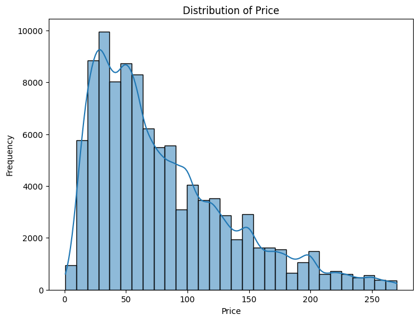

```python
# Create a histogram of the price column
plt.figure(figsize=(8, 6))
sns.histplot(data['price'], bins=30, kde=True)
plt.title('Distribution of Price')
plt.xlabel('Price')
plt.ylabel('Frequency')
plt.show()
```

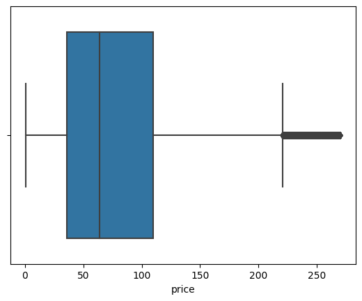

```python
# Create a box plot of the price column
sns.boxplot(data , x = 'price')
plt.show();
```

The data is right skewed and there are outliers present in price data column.

1. Check if there are any outliers in the price column. If present do the needful. (1 point)

```python
# Remove outlier
outliers = []
def detect_outliers_zscore(data):
    thres = 3
    mean = np.mean(data)
    std = np.std(data)
    # print(mean, std)
    for i in data:
        z_score = (i-mean)/std
        if (np.abs(z_score) > thres):
            outliers.append(i)
    return outliers# Driver code
sample_outliers = detect_outliers_zscore(data['price'])


median = np.median(data['price'])# Replace with median
for i in sample_outliers:
  data['price'] = np.where(data['price']==i, median , data['price'])
```

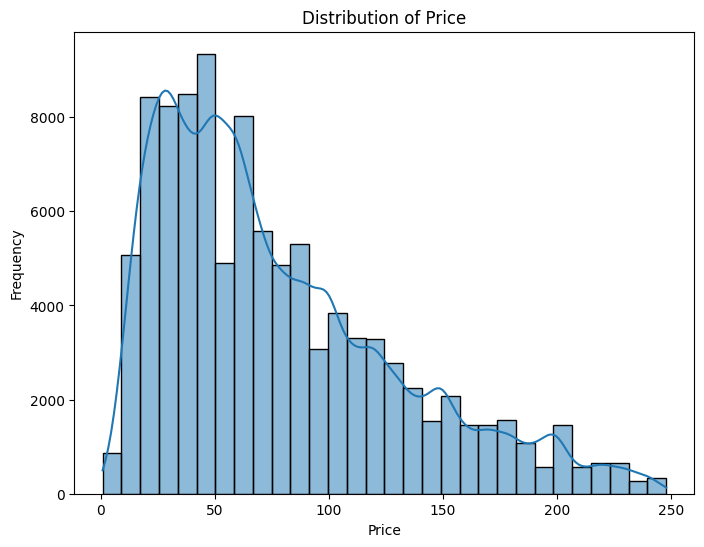

```python
# Create a histogram of the price column
plt.figure(figsize=(8, 6))
sns.histplot(data['price'], bins=30, kde=True)
plt.title('Distribution of Price')
plt.xlabel('Price')
plt.ylabel('Frequency')
plt.show()
```

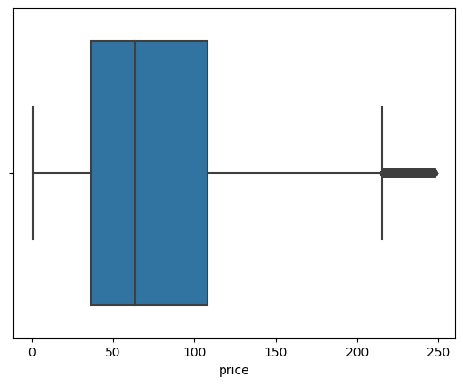

```python
# Create a box plot of the price column
sns.boxplot(data , x = 'price')
plt.show();
```

1. Check the distribution of the freight_value column. Share insights from the distribution. (1 point)

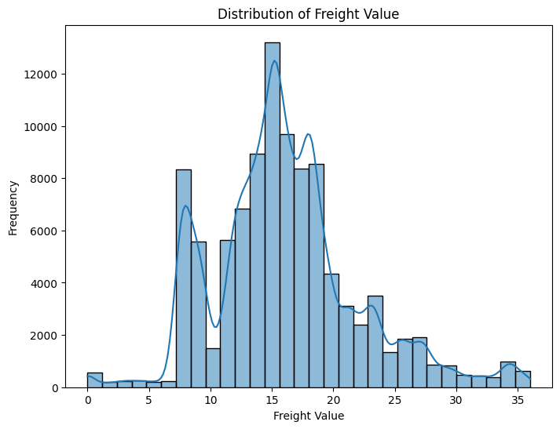

```python
# Create a histogram of the freight_value column
plt.figure(figsize=(8, 6))
sns.histplot(data['freight_value'], bins=30, kde=True)
plt.title('Distribution of Freight Value')
plt.xlabel('Freight Value')
plt.ylabel('Frequency')
plt.show()
```

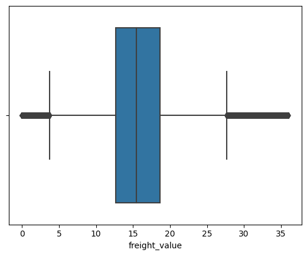

```python
# Create a box plot of the freight_value column
sns.boxplot(data , x = 'freight_value')
plt.show();
```

The data is left as well as right skewed with outliers on both ends.

1. Check if there are any outliers in the freight_value column. If present do the needful. (1 point)

```python
# Remove outliers
outliers = []
def detect_outliers_zscore(data):
    thres = 3
    mean = np.mean(data)
    std = np.std(data)
    # print(mean, std)
    for i in data:
        z_score = (i-mean)/std
        if (np.abs(z_score) > thres):
            outliers.append(i)
    return outliers# Driver code
sample_outliers = detect_outliers_zscore(data['freight_value'])


median = np.median(data['freight_value'])# Replace with median
for i in sample_outliers:
  data['freight_value'] = np.where(data['freight_value']==i, median , data['freight_value'])
```

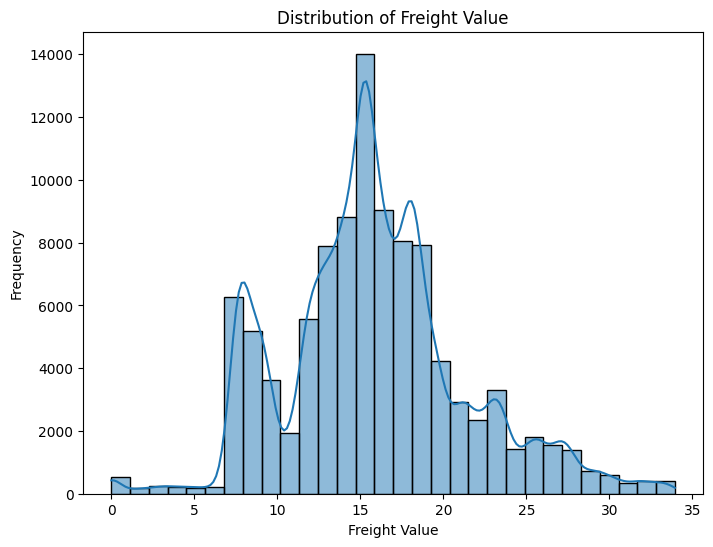

```python
# Create a histogram of the freight_value column
plt.figure(figsize=(8, 6))
sns.histplot(data['freight_value'], bins=30, kde=True)
plt.title('Distribution of Freight Value')
plt.xlabel('Freight Value')
plt.ylabel('Frequency')
plt.show()
```

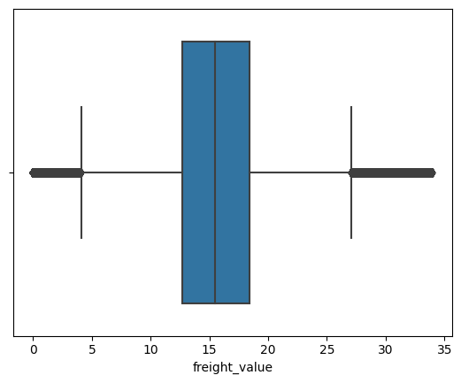

```python
sns.boxplot(data , x = 'freight_value')
plt.show();
```

1. Plot the countplot of the ‘payment_type’. Which payment mode is used the highest number of times to purchase the products. (2 points)

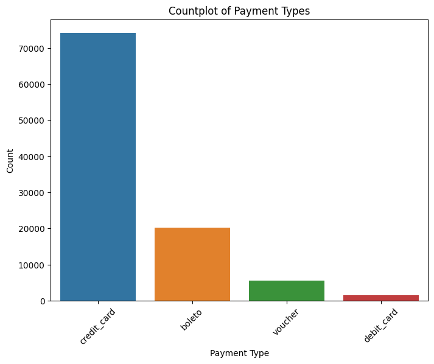

```python
# Create a countplot for payment_type
plt.figure(figsize=(8, 6))
sns.countplot(data=data, x='payment_type')
plt.title('Countplot of Payment Types')
plt.xlabel('Payment Type')
plt.ylabel('Count')
plt.xticks(rotation=45)  # Rotate x-axis labels for readability
plt.show()
```

Credit card is used the highest number of times to purchase the products.

1. Plot the countplot of the ‘payment_sequential’. Share your insight. (1 points)

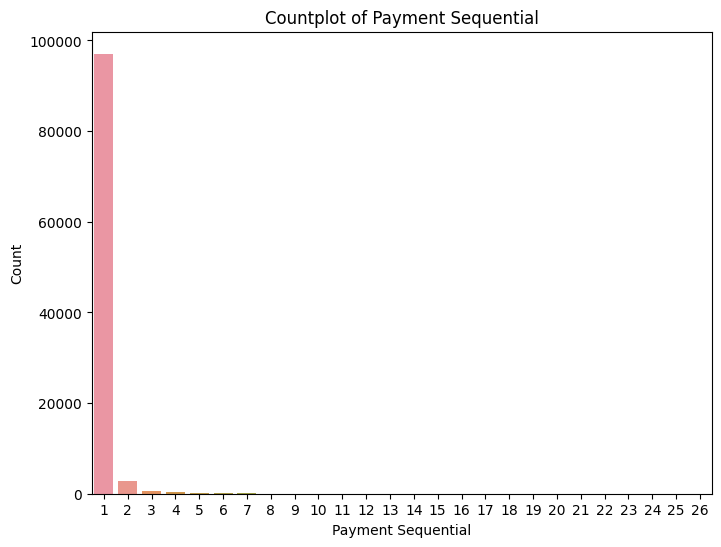

```python
# Create a countplot for payment_sequential
plt.figure(figsize=(8, 6))
sns.countplot(data=data, x='payment_sequential')
plt.title('Countplot of Payment Sequential')
plt.xlabel('Payment Sequential')
plt.ylabel('Count')
plt.show()
```

```python
# percentage of 1 present in payment sequential
c = (data['payment_sequential']==1).sum();
t = c/101335*100
print(t)
```

```
95.79118764494005
```

Payment sequential 1 is used the highest number of times which is 95.79% out of all other sequential.

1. Check the distribution of the payment_value column. Share insights from the distribution. (1 point)

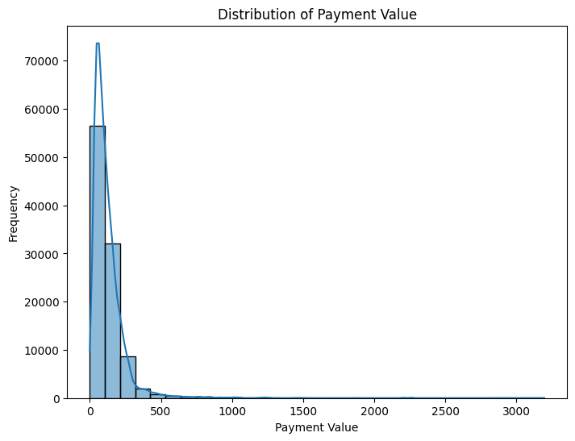

```python
# Create a histogram of the payment_value column
plt.figure(figsize=(8, 6))
sns.histplot(data['payment_value'], bins=30, kde=True)
plt.title('Distribution of Payment Value')
plt.xlabel('Payment Value')
plt.ylabel('Frequency')
plt.show()
```

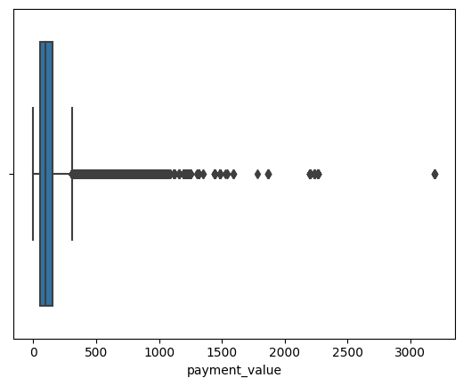

```python
# Create a box plot of the payment_value column
sns.boxplot(data , x = 'payment_value')
plt.show();
```

The data is highly right skewed with outliers.

1. Check if there are any outliers in the payment_value column. If present do the needful. (1 point)

```python
# Remove outliers
outliers = []
def detect_outliers_zscore(data):
    thres = 3
    mean = np.mean(data)
    std = np.std(data)
    # print(mean, std)
    for i in data:
        z_score = (i-mean)/std
        if (np.abs(z_score) > thres):
            outliers.append(i)
    return outliers# Driver code
sample_outliers = detect_outliers_zscore(data['payment_value'])


median = np.median(data['payment_value'])# Replace with median
for i in sample_outliers:
  data['payment_value'] = np.where(data['payment_value']==i, median , data['payment_value'])
```

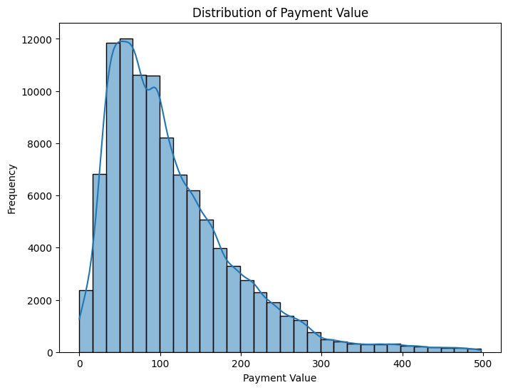

```python
# Create a histogram of the payment_value column
plt.figure(figsize=(8, 6))
sns.histplot(data['payment_value'], bins=30, kde=True)
plt.title('Distribution of Payment Value')
plt.xlabel('Payment Value')
plt.ylabel('Frequency')
plt.show()
```

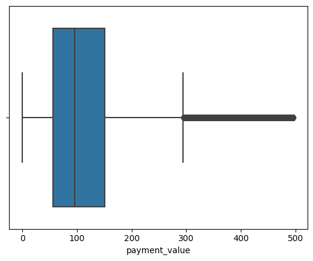

```python
# Create a box plot of the payment_value column
sns.boxplot(data , x = 'payment_value')
plt.show();
```

1. Plot the countplot of payment_installments. Report the ‘payment_installments’ which is used most often by the customers? ( 2 points)

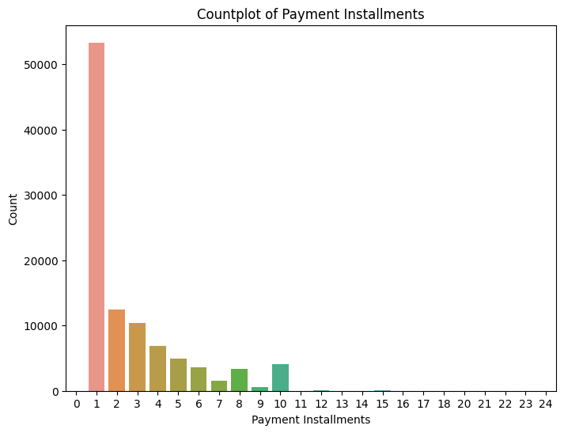

```python
# Create a countplot for payment_installments
plt.figure(figsize=(8, 6))
sns.countplot(data=data, x='payment_installments')
plt.title('Countplot of Payment Installments')
plt.xlabel('Payment Installments')
plt.ylabel('Count')
plt.show()
```

The ‘payment_installments’ which is used most often by the customers is 1

● **Bivariate Analysis ( 4 points)**

1. Perform bivariate analysis between the ‘payment_type’ and the ‘payment_installments’ and display the outcome using an appropriate plot. (1 point)

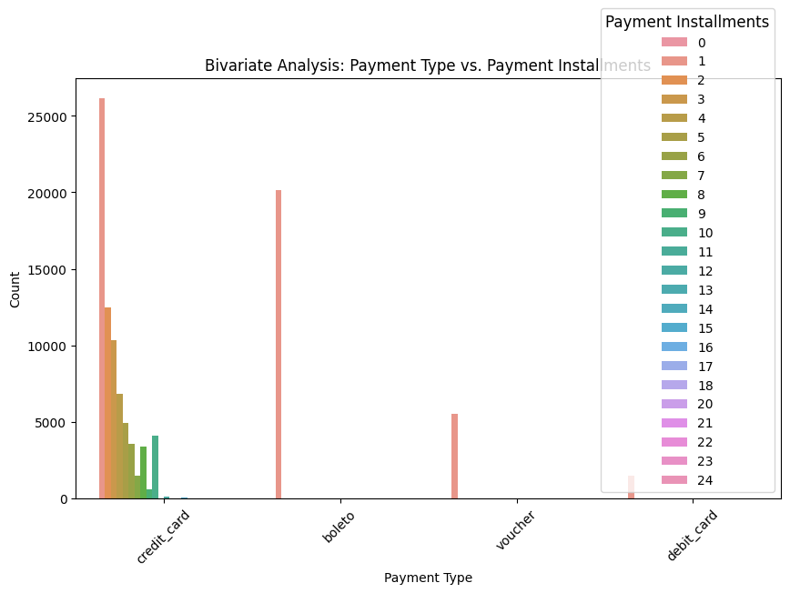

```python
# Create a grouped bar plot
plt.figure(figsize=(10, 6))
sns.countplot(data=data, x='payment_type', hue='payment_installments')
plt.title('Bivariate Analysis: Payment Type vs. Payment Installments')
plt.xlabel('Payment Type')
plt.ylabel('Count')
plt.xticks(rotation=45)  # Rotate x-axis labels for readability
plt.legend(title='Payment Installments', title_fontsize='12')
plt.show()
```

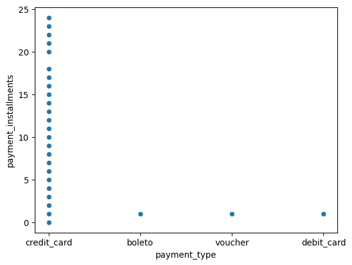

```python
# Create a scatter plot
sns.scatterplot(data , x = 'payment_type' , y = 'payment_installments' )
```

1. What is the maximum number of payment_installments in credit_card type. ( 1 point)

The maximum number of installments in payment type credit_card are 24

1. Create a dataframe which consists of a crosstab of the ‘payment_type’ and the ‘payment_installments’ and return the values as percentage. What is the percentage of 1st installment (i.e. payment_installments=1) with the boleto based payment. (2 points)

```python
# create a cross tab
cross_tab = pd.crosstab(data.payment_installments , data.payment_type)
crosstab_perc = cross_tab.apply(lambda x: x/x.sum(), axis=1)
crosstab_perc = crosstab_perc.applymap(lambda x: '{:.1%}'.format(x))
crosstab_perc
```

| payment_type payment_installments | boleto | credit_card | debit_card | voucher |
| --- | --- | --- | --- | --- |
| 0 | 0.0% | 100.0% | 0.0% | 0.0% |
| 1 | 37.8% | 49.0% | 2.8% | 10.3% |
| 2 | 0.0% | 100.0% | 0.0% | 0.0% |
| 3 | 0.0% | 100.0% | 0.0% | 0.0% |
| 4 | 0.0% | 100.0% | 0.0% | 0.0% |
| 5 | 0.0% | 100.0% | 0.0% | 0.0% |
| 6 | 0.0% | 100.0% | 0.0% | 0.0% |
| 7 | 0.0% | 100.0% | 0.0% | 0.0% |
| 8 | 0.0% | 100.0% | 0.0% | 0.0% |
| 9 | 0.0% | 100.0% | 0.0% | 0.0% |
| 10 | 0.0% | 100.0% | 0.0% | 0.0% |
| 11 | 0.0% | 100.0% | 0.0% | 0.0% |
| 12 | 0.0% | 100.0% | 0.0% | 0.0% |
| 13 | 0.0% | 100.0% | 0.0% | 0.0% |
| 14 | 0.0% | 100.0% | 0.0% | 0.0% |
| 15 | 0.0% | 100.0% | 0.0% | 0.0% |
| 16 | 0.0% | 100.0% | 0.0% | 0.0% |
| 17 | 0.0% | 100.0% | 0.0% | 0.0% |
| 18 | 0.0% | 100.0% | 0.0% | 0.0% |
| 20 | 0.0% | 100.0% | 0.0% | 0.0% |
| 21 | 0.0% | 100.0% | 0.0% | 0.0% |
| 22 | 0.0% | 100.0% | 0.0% | 0.0% |
| 23 | 0.0% | 100.0% | 0.0% | 0.0% |
| 24 | 0.0% | 100.0% | 0.0% | 0.0% |

The percentage of 1st installment (i.e. payment_installments=1) with the boleto based payment is 37.8%

● **Multivariate Analysis (4 points)**

1. Plot a heatmap which consists of the correlation between all the columns of the dataframe. (2 points)

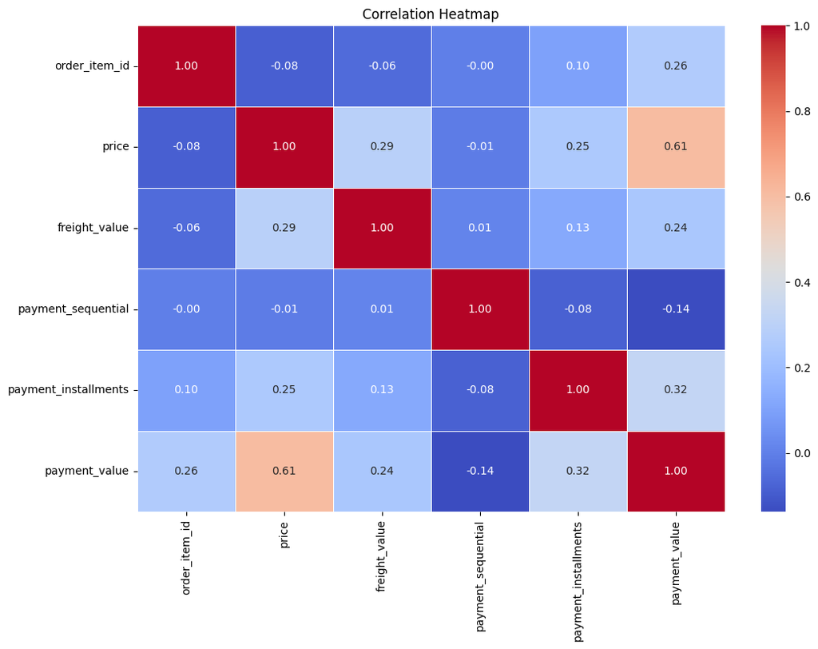

```python
# Calculate the correlation matrix
correlation_matrix = data.corr()

# Create a heatmap of the correlation matrix
plt.figure(figsize=(12, 8))
sns.heatmap(correlation_matrix, annot=True, cmap='coolwarm', fmt=".2f", linewidths=0.5)
plt.title('Correlation Heatmap')
plt.show()
```

1. Plot a pairplot of all the columns using hue as the ‘payment_type’ and share your insights. (2 points)

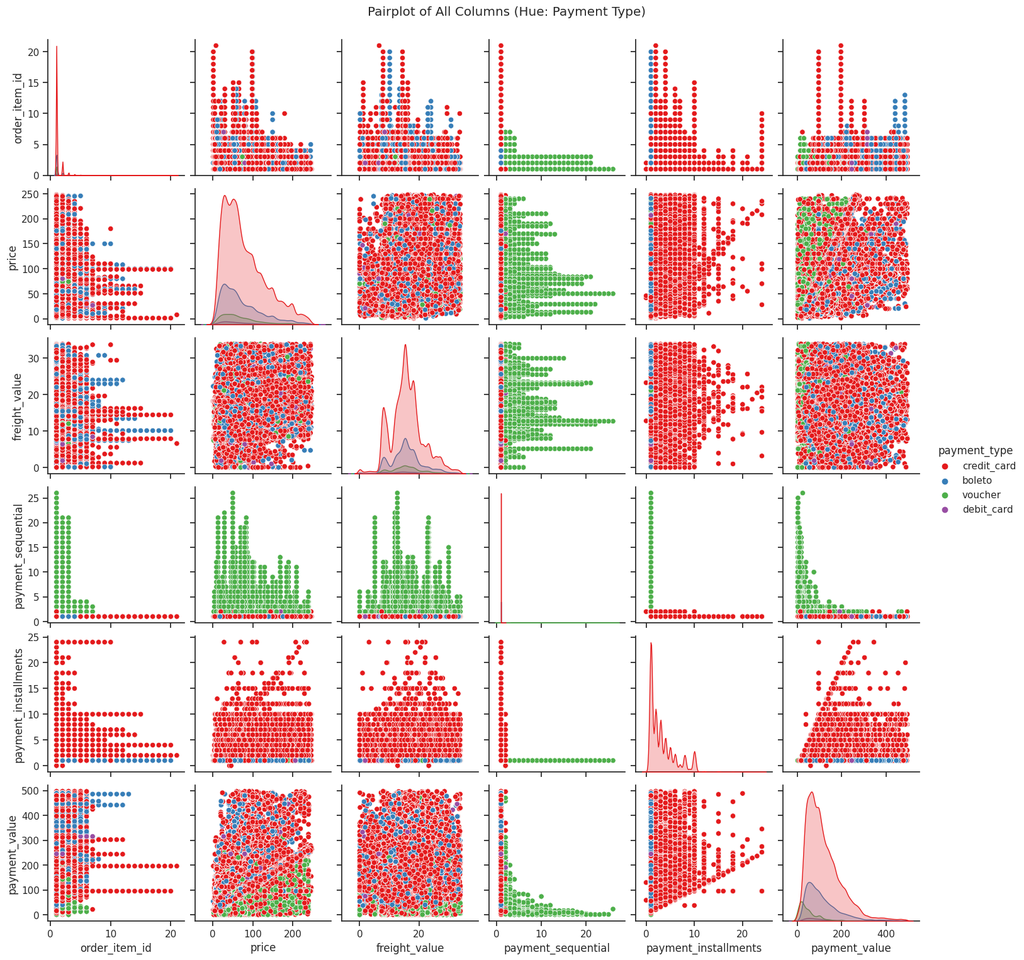

```python
# Set the style of the pairplot
sns.set(style="ticks")

# Create a pairplot with 'payment_type' as the hue
sns.pairplot(data, hue='payment_type', palette='Set1')
plt.suptitle('Pairplot of All Columns (Hue: Payment Type)', y=1.02)
plt.show()
```

● Hypothesis Testing (9 points)

1. Is there any significant difference in the payment values of the customers who are paying through credit card and the customers who are paying through the ‘boleto’. (3 points)

a. Write the null hypothesis and alternative hypothesis for the above case.

Null hypothesis (H0): There is no significant difference in the payment values of customers who are paying through credit card and customers who are paying through the 'boleto'.

Alternative hypothesis (Ha): There is a significant difference in the payment values of customers who are paying through credit card and customers who are paying through the 'boleto'.

b. Define the test that should be used and the significance level.

To test the hypothesis, a statistical test can be used, such as the independent samples t-test. The significance level, denoted as alpha (α), is a predetermined threshold used to determine the level of significance required to reject the null hypothesis. A common significance level is 0.05 (5%).

c. Perform the hypothesis testing and report your conclusion.

```python
from scipy.stats import ttest_ind
temp1 = data[data['payment_type'] == 'credit_card']['payment_value']
temp2 = data[data['payment_type']=='boleto']['payment_value']
t_stats, p_value = ttest_ind(temp1 , temp2)
print('T-statistic: ', '%1.2f' % t_stats, '\n\nP value: ', '%1.2f' %  p_value)

print('\nResult of Statistical Test:')

if p_value > 0.05:
    print('Null Hypothesis (H0) accepted - There is no significant difference in the payment values of customers who are paying through credit card and customers who are paying through the boleto')
else:
    print('Null Hypothesis (H0) rejected (Alternate Hypothesis (H1) accepted) - There is a significant difference in the payment values of customers who are paying through credit card and customers who are paying through the boleto')
```

```
T-statistic:  6.12

P value:  0.00

Result of Statistical Test:
Null Hypothesis (H0) rejected (Alternate Hypothesis (H1) accepted) - There is a significant difference in the payment values of customers who are paying through credit card and customers who are paying through the boleto
```

Null Hypothesis (H0) rejected (Alternate Hypothesis (H1) accepted) - There is a significant difference in the payment values of customers who are paying through credit card and customers who are paying through the boleto

1. Is there any significant difference among the means of the payment_value of the payments made through credit_card, boleto, voucher, debit_card. (3 points)

a. Write the null hypothesis and alternative hypothesis for the above case.

Null Hypothesis (H0): There is no significant difference among the means of payment values for different payment methods.

Alternative Hypothesis (Ha): There is a significant difference among the means of payment values for different payment methods.

b. Define the test that should be used and the significance level.

Test: One-way ANOVA test. Significance Level (alpha): α = 0.05. This represents the probability of making a Type I error (incorrectly rejecting the null hypothesis when it's true).

c. Perform the hypothesis testing and report your conclusion.

```python
import scipy.stats as stats

# Create separate data series for each payment method
credit_card = data[data['payment_type'] == 'credit_card']['payment_value']
boleto = data[data['payment_type'] == 'boleto']['payment_value']
voucher = data[data['payment_type'] == 'voucher']['payment_value']
debit_card = data[data['payment_type'] == 'debit_card']['payment_value']

# Perform one-way ANOVA
f_statistic, p_value = stats.f_oneway(credit_card, boleto, voucher, debit_card)

# Check the p-value against your chosen significance level (alpha)
alpha = 0.05
if p_value < alpha:
    print("Reject the null hypothesis. There is a significant difference among the means of payment values.")
else:
    print("Fail to reject the null hypothesis. There is no significant difference among the means of payment values.")
```

```
Reject the null hypothesis. There is a significant difference among the means of payment values.
```

Reject the null hypothesis. There is a significant difference among the means of the payment_value of the payments made through credit_card, boleto, voucher, debit_card.

1. Is there any significant difference in the price of the item for the customers who are paying through credit card and customers who are paying through the boleto. (3 points)

a. Write the null hypothesis and alternative hypothesis for the above case.

Null Hypothesis (H0): There is no significant difference in the price of the item between customers paying through credit card and customers paying through boleto.

Alternative Hypothesis (Ha): There is a significant difference in the price of the item between customers paying through credit card and customers paying through boleto.

b. Define the test that should be used and the significance level.

Test: Two-sample independent t-test. Significance Level (alpha): α = 0.05. This represents the probability of making a Type I error (incorrectly rejecting the null hypothesis when it's true).

c. Perform the hypothesis testing and report your conclusion

```python
# Create separate data series for credit card and boleto payments
credit_card_prices = data[data['payment_type'] == 'credit_card']['price']
boleto_prices = data[data['payment_type'] == 'boleto']['price']

# Perform the two-sample t-test
t_statistic, p_value = stats.ttest_ind(credit_card_prices, boleto_prices, equal_var=False)

# Check the p-value against your chosen significance level (alpha)
alpha = 0.05
if p_value < alpha:
    print("Reject the null hypothesis. There is a significant difference in the price of the item between credit card and boleto payments.")
else:
    print("Fail to reject the null hypothesis. There is no significant difference in the price of the item between credit card and boleto payments.")
```

```
Reject the null hypothesis. There is a significant difference in the price of the item between credit card and boleto payments.
```

Reject the null hypothesis. There is a significant difference in the price of the item between credit card and boleto payments.